# Risk Factor Analysis

## Outcome Variable

**Outcome Variable:** ever_stunted

## Predictor Variables

**Intervention Variable:** gagebrth

**Adjustment Set:**

unadjusted

## Stratifying Variables

The analysis was stratified on these variable(s):

- agecat
- studyid
- country

## Data Summary

| agecat | studyid | country | gagebrth | ever_stunted | n_cell | n |
| --- | --- | --- | --- | --- | --- | --- |
| 0-6 months | ki1000108-CMC-V-BCS-2002 | INDIA | [273-287) | 0 | 123 | 346 |
| 0-6 months | ki1000108-CMC-V-BCS-2002 | INDIA | [273-287) | 1 | 23 | 346 |
| 0-6 months | ki1000108-CMC-V-BCS-2002 | INDIA | <259 | 0 | 30 | 346 |
| 0-6 months | ki1000108-CMC-V-BCS-2002 | INDIA | <259 | 1 | 17 | 346 |
| 0-6 months | ki1000108-CMC-V-BCS-2002 | INDIA | [259-273) | 0 | 56 | 346 |
| 0-6 months | ki1000108-CMC-V-BCS-2002 | INDIA | [259-273) | 1 | 18 | 346 |
| 0-6 months | ki1000108-CMC-V-BCS-2002 | INDIA | >=287 | 0 | 65 | 346 |
| 0-6 months | ki1000108-CMC-V-BCS-2002 | INDIA | >=287 | 1 | 14 | 346 |
| 0-6 months | ki1000108-IRC | INDIA | [273-287) | 0 | 149 | 390 |
| 0-6 months | ki1000108-IRC | INDIA | [273-287) | 1 | 16 | 390 |
| 0-6 months | ki1000108-IRC | INDIA | <259 | 0 | 30 | 390 |
| 0-6 months | ki1000108-IRC | INDIA | <259 | 1 | 10 | 390 |
| 0-6 months | ki1000108-IRC | INDIA | [259-273) | 0 | 83 | 390 |
| 0-6 months | ki1000108-IRC | INDIA | [259-273) | 1 | 9 | 390 |
| 0-6 months | ki1000108-IRC | INDIA | >=287 | 0 | 79 | 390 |
| 0-6 months | ki1000108-IRC | INDIA | >=287 | 1 | 14 | 390 |
| 0-6 months | ki1000109-EE | PAKISTAN | [273-287) | 0 | 17 | 379 |
| 0-6 months | ki1000109-EE | PAKISTAN | [273-287) | 1 | 7 | 379 |
| 0-6 months | ki1000109-EE | PAKISTAN | <259 | 0 | 160 | 379 |
| 0-6 months | ki1000109-EE | PAKISTAN | <259 | 1 | 85 | 379 |
| 0-6 months | ki1000109-EE | PAKISTAN | [259-273) | 0 | 71 | 379 |
| 0-6 months | ki1000109-EE | PAKISTAN | [259-273) | 1 | 38 | 379 |
| 0-6 months | ki1000109-EE | PAKISTAN | >=287 | 0 | 1 | 379 |
| 0-6 months | ki1000109-EE | PAKISTAN | >=287 | 1 | 0 | 379 |
| 0-6 months | ki1000304b-SAS-CompFeed | INDIA | [273-287) | 0 | 37 | 1512 |
| 0-6 months | ki1000304b-SAS-CompFeed | INDIA | [273-287) | 1 | 5 | 1512 |
| 0-6 months | ki1000304b-SAS-CompFeed | INDIA | <259 | 0 | 834 | 1512 |
| 0-6 months | ki1000304b-SAS-CompFeed | INDIA | <259 | 1 | 376 | 1512 |
| 0-6 months | ki1000304b-SAS-CompFeed | INDIA | [259-273) | 0 | 206 | 1512 |
| 0-6 months | ki1000304b-SAS-CompFeed | INDIA | [259-273) | 1 | 51 | 1512 |

[output cut: 270 more lines]

The following strata were considered:

- agecat: 0-24 months, studyid: ki1000108-CMC-V-BCS-2002, country: INDIA
- agecat: 0-24 months, studyid: ki1000108-IRC, country: INDIA
- agecat: 0-24 months, studyid: ki1000109-EE, country: PAKISTAN
- agecat: 0-24 months, studyid: ki1000304b-SAS-CompFeed, country: INDIA
- agecat: 0-24 months, studyid: ki1017093c-NIH-Crypto, country: BANGLADESH
- agecat: 0-24 months, studyid: ki1066203-TanzaniaChild2, country: TANZANIA, UNITED REPUBLIC OF
- agecat: 0-24 months, studyid: ki1101329-Keneba, country: GAMBIA
- agecat: 0-24 months, studyid: ki1113344-GMS-Nepal, country: NEPAL
- agecat: 0-24 months, studyid: ki1119695-PROBIT, country: BELARUS
- agecat: 0-24 months, studyid: ki1135781-COHORTS, country: GUATEMALA
- agecat: 0-24 months, studyid: ki1135781-COHORTS, country: INDIA
- agecat: 0-24 months, studyid: ki1135781-COHORTS, country: PHILIPPINES
- agecat: 0-24 months, studyid: kiGH5241-JiVitA-3, country: BANGLADESH
- agecat: 0-6 months, studyid: ki1000108-CMC-V-BCS-2002, country: INDIA
- agecat: 0-6 months, studyid: ki1000108-IRC, country: INDIA
- agecat: 0-6 months, studyid: ki1000109-EE, country: PAKISTAN
- agecat: 0-6 months, studyid: ki1000304b-SAS-CompFeed, country: INDIA
- agecat: 0-6 months, studyid: ki1017093c-NIH-Crypto, country: BANGLADESH
- agecat: 0-6 months, studyid: ki1066203-TanzaniaChild2, country: TANZANIA, UNITED REPUBLIC OF
- agecat: 0-6 months, studyid: ki1101329-Keneba, country: GAMBIA
- agecat: 0-6 months, studyid: ki1113344-GMS-Nepal, country: NEPAL
- agecat: 0-6 months, studyid: ki1119695-PROBIT, country: BELARUS
- agecat: 0-6 months, studyid: ki1135781-COHORTS, country: GUATEMALA
- agecat: 0-6 months, studyid: ki1135781-COHORTS, country: INDIA
- agecat: 0-6 months, studyid: ki1135781-COHORTS, country: PHILIPPINES
- agecat: 0-6 months, studyid: kiGH5241-JiVitA-3, country: BANGLADESH
- agecat: 6-24 months, studyid: ki1000108-CMC-V-BCS-2002, country: INDIA
- agecat: 6-24 months, studyid: ki1000108-IRC, country: INDIA
- agecat: 6-24 months, studyid: ki1000109-EE, country: PAKISTAN
- agecat: 6-24 months, studyid: ki1000304b-SAS-CompFeed, country: INDIA
- agecat: 6-24 months, studyid: ki1017093c-NIH-Crypto, country: BANGLADESH
- agecat: 6-24 months, studyid: ki1066203-TanzaniaChild2, country: TANZANIA, UNITED REPUBLIC OF
- agecat: 6-24 months, studyid: ki1101329-Keneba, country: GAMBIA
- agecat: 6-24 months, studyid: ki1113344-GMS-Nepal, country: NEPAL
- agecat: 6-24 months, studyid: ki1119695-PROBIT, country: BELARUS
- agecat: 6-24 months, studyid: ki1135781-COHORTS, country: GUATEMALA
- agecat: 6-24 months, studyid: ki1135781-COHORTS, country: INDIA
- agecat: 6-24 months, studyid: ki1135781-COHORTS, country: PHILIPPINES
- agecat: 6-24 months, studyid: kiGH5241-JiVitA-3, country: BANGLADESH

## Methods Detail

We’re interested in the causal parameters $E[Y_a]$ for all values of $a \in \mathcal{A}$. These parameters represent the mean outcome if, possibly contrary to fact, we intervened to set all units to have $A=a$. Under the randomization and positivity assumptions, these are identified by the statistical parameters $\psi_a=E_W[E_{Y|A,W}(Y|A=a,W)]$. In addition, we’re interested in the mean of $Y$, $E[Y]$ under no intervention (the observed mean). We will estimate these parameters by using SuperLearner to fit the relevant likelihood factors – $E_{Y|A,W}(Y|A=a,W)$ and $p(A=a|W)$, and then updating our likelihood fit using a joint TMLE.

For unadjusted analyses ($W=\{\}$), initial likelihoods were estimated using Lrnr_glm to estimate the simple $E(Y|A)$ and Lrnr_mean to estimate $p(A)$. For adjusted analyses, a small library containing Lrnr_glmnet, Lrnr_xgboost, and Lrnr_mean was used.

Having estimated these parameters, we will then use the delta method to estimate relative risks and attributable risks relative to a prespecified baseline level of $A$.

[output not shown]

# Results Detail

## Results Plots

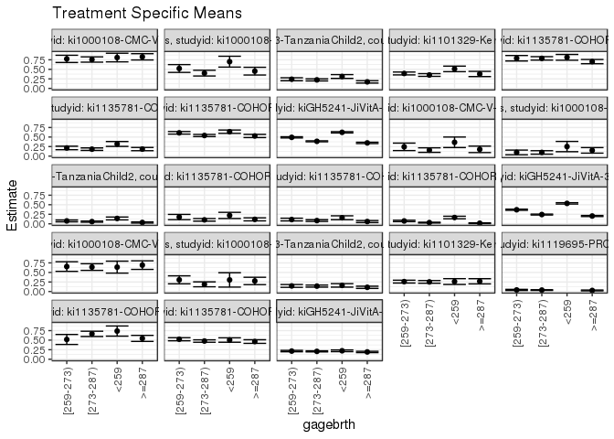

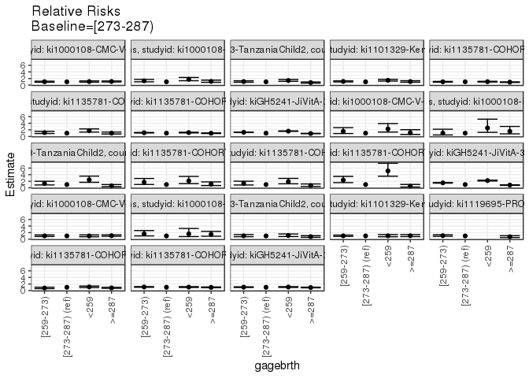

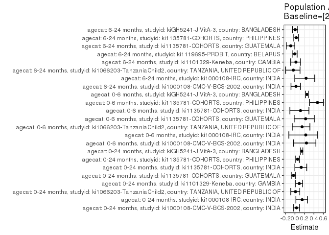

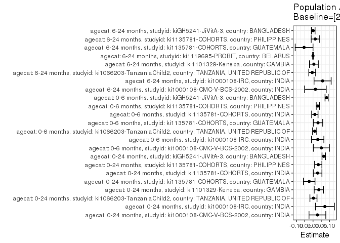

## Results Table

### Parameter: TSM

| agecat | studyid | country | intervention_level | baseline_level | estimate | ci_lower | ci_upper |
| --- | --- | --- | --- | --- | --- | --- | --- |
| 0-24 months | ki1000108-CMC-V-BCS-2002 | INDIA | [273-287) | NA | 0.7567568 | 0.6875362 | 0.8259773 |
| 0-24 months | ki1000108-CMC-V-BCS-2002 | INDIA | <259 | NA | 0.8085106 | 0.6958599 | 0.9211613 |
| 0-24 months | ki1000108-CMC-V-BCS-2002 | INDIA | [259-273) | NA | 0.7733333 | 0.6784447 | 0.8682220 |
| 0-24 months | ki1000108-CMC-V-BCS-2002 | INDIA | >=287 | NA | 0.8271605 | 0.7447008 | 0.9096201 |
| 0-24 months | ki1000108-IRC | INDIA | [273-287) | NA | 0.4000000 | 0.3251539 | 0.4748461 |
| 0-24 months | ki1000108-IRC | INDIA | <259 | NA | 0.7000000 | 0.5578047 | 0.8421953 |
| 0-24 months | ki1000108-IRC | INDIA | [259-273) | NA | 0.5217391 | 0.4195344 | 0.6239438 |
| 0-24 months | ki1000108-IRC | INDIA | >=287 | NA | 0.4516129 | 0.3503405 | 0.5528853 |
| 0-24 months | ki1066203-TanzaniaChild2 | TANZANIA, UNITED REPUBLIC OF | [273-287) | NA | 0.2239819 | 0.1964928 | 0.2514710 |
| 0-24 months | ki1066203-TanzaniaChild2 | TANZANIA, UNITED REPUBLIC OF | <259 | NA | 0.3119266 | 0.2617023 | 0.3621509 |
| 0-24 months | ki1066203-TanzaniaChild2 | TANZANIA, UNITED REPUBLIC OF | [259-273) | NA | 0.2399151 | 0.2013411 | 0.2784890 |
| 0-24 months | ki1066203-TanzaniaChild2 | TANZANIA, UNITED REPUBLIC OF | >=287 | NA | 0.1713287 | 0.1404433 | 0.2022140 |
| 0-24 months | ki1101329-Keneba | GAMBIA | [273-287) | NA | 0.3514706 | 0.3155759 | 0.3873653 |
| 0-24 months | ki1101329-Keneba | GAMBIA | <259 | NA | 0.5111111 | 0.4380642 | 0.5841581 |
| 0-24 months | ki1101329-Keneba | GAMBIA | [259-273) | NA | 0.3917051 | 0.3541973 | 0.4292129 |
| 0-24 months | ki1101329-Keneba | GAMBIA | >=287 | NA | 0.3782383 | 0.3098012 | 0.4466755 |
| 0-24 months | ki1135781-COHORTS | GUATEMALA | [273-287) | NA | 0.7865854 | 0.7422181 | 0.8309526 |
| 0-24 months | ki1135781-COHORTS | GUATEMALA | <259 | NA | 0.8137255 | 0.7381241 | 0.8893269 |
| 0-24 months | ki1135781-COHORTS | GUATEMALA | [259-273) | NA | 0.7903226 | 0.7186288 | 0.8620164 |
| 0-24 months | ki1135781-COHORTS | GUATEMALA | >=287 | NA | 0.7022901 | 0.6468889 | 0.7576912 |
| 0-24 months | ki1135781-COHORTS | INDIA | [273-287) | NA | 0.1821561 | 0.1495295 | 0.2147828 |
| 0-24 months | ki1135781-COHORTS | INDIA | <259 | NA | 0.3186275 | 0.2546650 | 0.3825899 |
| 0-24 months | ki1135781-COHORTS | INDIA | [259-273) | NA | 0.2135922 | 0.1678788 | 0.2593057 |
| 0-24 months | ki1135781-COHORTS | INDIA | >=287 | NA | 0.1843750 | 0.1418712 | 0.2268788 |
| 0-24 months | ki1135781-COHORTS | PHILIPPINES | [273-287) | NA | 0.5402202 | 0.5117916 | 0.5686487 |
| 0-24 months | ki1135781-COHORTS | PHILIPPINES | <259 | NA | 0.6391304 | 0.5952359 | 0.6830250 |
| 0-24 months | ki1135781-COHORTS | PHILIPPINES | [259-273) | NA | 0.6100478 | 0.5769801 | 0.6431156 |
| 0-24 months | ki1135781-COHORTS | PHILIPPINES | >=287 | NA | 0.5279279 | 0.4863881 | 0.5694678 |
| 0-24 months | kiGH5241-JiVitA-3 | BANGLADESH | [273-287) | NA | 0.3877143 | 0.3747858 | 0.4006427 |
| 0-24 months | kiGH5241-JiVitA-3 | BANGLADESH | <259 | NA | 0.6231334 | 0.6066016 | 0.6396652 |

[output cut: 61 more lines]

### Parameter: E(Y)

| agecat | studyid | country | intervention_level | baseline_level | estimate | ci_lower | ci_upper |
| --- | --- | --- | --- | --- | --- | --- | --- |
| 0-24 months | ki1000108-CMC-V-BCS-2002 | INDIA | NA | NA | 0.7834758 | 0.7403259 | 0.8266257 |
| 0-24 months | ki1000108-IRC | INDIA | NA | NA | 0.4717949 | 0.4221869 | 0.5214028 |
| 0-24 months | ki1066203-TanzaniaChild2 | TANZANIA, UNITED REPUBLIC OF | NA | NA | 0.2267081 | 0.2094190 | 0.2439972 |
| 0-24 months | ki1101329-Keneba | GAMBIA | NA | NA | 0.3867371 | 0.3636073 | 0.4098669 |
| 0-24 months | ki1135781-COHORTS | GUATEMALA | NA | NA | 0.7634804 | 0.7343060 | 0.7926548 |
| 0-24 months | ki1135781-COHORTS | INDIA | NA | NA | 0.2100656 | 0.1884951 | 0.2316362 |
| 0-24 months | ki1135781-COHORTS | PHILIPPINES | NA | NA | 0.5722296 | 0.5546161 | 0.5898431 |
| 0-24 months | kiGH5241-JiVitA-3 | BANGLADESH | NA | NA | 0.4527871 | 0.4444343 | 0.4611400 |
| 0-6 months | ki1000108-CMC-V-BCS-2002 | INDIA | NA | NA | 0.2080925 | 0.1652570 | 0.2509280 |
| 0-6 months | ki1000108-IRC | INDIA | NA | NA | 0.1256410 | 0.0927040 | 0.1585780 |
| 0-6 months | ki1066203-TanzaniaChild2 | TANZANIA, UNITED REPUBLIC OF | NA | NA | 0.0678793 | 0.0574928 | 0.0782659 |
| 0-6 months | ki1135781-COHORTS | GUATEMALA | NA | NA | 0.1345408 | 0.1104700 | 0.1586115 |
| 0-6 months | ki1135781-COHORTS | INDIA | NA | NA | 0.0961538 | 0.0804339 | 0.1118738 |
| 0-6 months | ki1135781-COHORTS | PHILIPPINES | NA | NA | 0.0613456 | 0.0528029 | 0.0698884 |
| 0-6 months | kiGH5241-JiVitA-3 | BANGLADESH | NA | NA | 0.3255272 | 0.3180302 | 0.3330241 |
| 6-24 months | ki1000108-CMC-V-BCS-2002 | INDIA | NA | NA | 0.6556777 | 0.5992111 | 0.7121442 |
| 6-24 months | ki1000108-IRC | INDIA | NA | NA | 0.2469136 | 0.1998872 | 0.2939400 |
| 6-24 months | ki1066203-TanzaniaChild2 | TANZANIA, UNITED REPUBLIC OF | NA | NA | 0.1375936 | 0.1213893 | 0.1537978 |
| 6-24 months | ki1101329-Keneba | GAMBIA | NA | NA | 0.2578837 | 0.2351779 | 0.2805894 |
| 6-24 months | ki1119695-PROBIT | BELARUS | NA | NA | 0.0380298 | 0.0285924 | 0.0474672 |
| 6-24 months | ki1135781-COHORTS | GUATEMALA | NA | NA | 0.6107226 | 0.5645294 | 0.6569158 |
| 6-24 months | ki1135781-COHORTS | PHILIPPINES | NA | NA | 0.4900272 | 0.4691618 | 0.5108926 |
| 6-24 months | kiGH5241-JiVitA-3 | BANGLADESH | NA | NA | 0.2071640 | 0.1978526 | 0.2164754 |

### Parameter: RR

| agecat | studyid | country | intervention_level | baseline_level | estimate | ci_lower | ci_upper |
| --- | --- | --- | --- | --- | --- | --- | --- |
| 0-24 months | ki1000108-CMC-V-BCS-2002 | INDIA | [273-287) | [273-287) | 1.0000000 | 1.0000000 | 1.0000000 |
| 0-24 months | ki1000108-CMC-V-BCS-2002 | INDIA | <259 | [273-287) | 1.0683891 | 0.9043660 | 1.2621607 |
| 0-24 months | ki1000108-CMC-V-BCS-2002 | INDIA | [259-273) | [273-287) | 1.0219048 | 0.8768888 | 1.1909028 |
| 0-24 months | ki1000108-CMC-V-BCS-2002 | INDIA | >=287 | [273-287) | 1.0930335 | 0.9547186 | 1.2513868 |
| 0-24 months | ki1000108-IRC | INDIA | [273-287) | [273-287) | 1.0000000 | 1.0000000 | 1.0000000 |
| 0-24 months | ki1000108-IRC | INDIA | <259 | [273-287) | 1.7500000 | 1.3276812 | 2.3066532 |
| 0-24 months | ki1000108-IRC | INDIA | [259-273) | [273-287) | 1.3043478 | 0.9948183 | 1.7101850 |
| 0-24 months | ki1000108-IRC | INDIA | >=287 | [273-287) | 1.1290323 | 0.8430762 | 1.5119795 |
| 0-24 months | ki1066203-TanzaniaChild2 | TANZANIA, UNITED REPUBLIC OF | [273-287) | [273-287) | 1.0000000 | 1.0000000 | 1.0000000 |
| 0-24 months | ki1066203-TanzaniaChild2 | TANZANIA, UNITED REPUBLIC OF | <259 | [273-287) | 1.3926420 | 1.1374039 | 1.7051566 |
| 0-24 months | ki1066203-TanzaniaChild2 | TANZANIA, UNITED REPUBLIC OF | [259-273) | [273-287) | 1.0711360 | 0.8749835 | 1.3112617 |
| 0-24 months | ki1066203-TanzaniaChild2 | TANZANIA, UNITED REPUBLIC OF | >=287 | [273-287) | 0.7649219 | 0.6150430 | 0.9513247 |
| 0-24 months | ki1101329-Keneba | GAMBIA | [273-287) | [273-287) | 1.0000000 | 1.0000000 | 1.0000000 |
| 0-24 months | ki1101329-Keneba | GAMBIA | <259 | [273-287) | 1.4542073 | 1.2199424 | 1.7334581 |
| 0-24 months | ki1101329-Keneba | GAMBIA | [259-273) | [273-287) | 1.1144747 | 0.9688811 | 1.2819466 |
| 0-24 months | ki1101329-Keneba | GAMBIA | >=287 | [273-287) | 1.0761593 | 0.8742661 | 1.3246755 |
| 0-24 months | ki1135781-COHORTS | GUATEMALA | [273-287) | [273-287) | 1.0000000 | 1.0000000 | 1.0000000 |
| 0-24 months | ki1135781-COHORTS | GUATEMALA | <259 | [273-287) | 1.0345037 | 0.9279592 | 1.1532812 |
| 0-24 months | ki1135781-COHORTS | GUATEMALA | [259-273) | [273-287) | 1.0047512 | 0.9029567 | 1.1180215 |
| 0-24 months | ki1135781-COHORTS | GUATEMALA | >=287 | [273-287) | 0.8928339 | 0.8103153 | 0.9837558 |
| 0-24 months | ki1135781-COHORTS | INDIA | [273-287) | [273-287) | 1.0000000 | 1.0000000 | 1.0000000 |
| 0-24 months | ki1135781-COHORTS | INDIA | <259 | [273-287) | 1.7491997 | 1.3365925 | 2.2891791 |
| 0-24 months | ki1135781-COHORTS | INDIA | [259-273) | [273-287) | 1.1725778 | 0.8870286 | 1.5500500 |
| 0-24 months | ki1135781-COHORTS | INDIA | >=287 | [273-287) | 1.0121811 | 0.7559150 | 1.3553251 |
| 0-24 months | ki1135781-COHORTS | PHILIPPINES | [273-287) | [273-287) | 1.0000000 | 1.0000000 | 1.0000000 |
| 0-24 months | ki1135781-COHORTS | PHILIPPINES | <259 | [273-287) | 1.1830925 | 1.0850325 | 1.2900148 |
| 0-24 months | ki1135781-COHORTS | PHILIPPINES | [259-273) | [273-287) | 1.1292578 | 1.0470877 | 1.2178762 |
| 0-24 months | ki1135781-COHORTS | PHILIPPINES | >=287 | [273-287) | 0.9772459 | 0.8889829 | 1.0742721 |
| 0-24 months | kiGH5241-JiVitA-3 | BANGLADESH | [273-287) | [273-287) | 1.0000000 | 1.0000000 | 1.0000000 |
| 0-24 months | kiGH5241-JiVitA-3 | BANGLADESH | <259 | [273-287) | 1.6071974 | 1.5392092 | 1.6781887 |

[output cut: 61 more lines]

### Parameter: PAR

| agecat | studyid | country | intervention_level | baseline_level | estimate | ci_lower | ci_upper |
| --- | --- | --- | --- | --- | --- | --- | --- |
| 0-24 months | ki1000108-CMC-V-BCS-2002 | INDIA | [273-287) | NA | 0.0267190 | -0.0243957 | 0.0778338 |
| 0-24 months | ki1000108-IRC | INDIA | [273-287) | NA | 0.0717949 | 0.0141513 | 0.1294385 |
| 0-24 months | ki1066203-TanzaniaChild2 | TANZANIA, UNITED REPUBLIC OF | [273-287) | NA | 0.0027262 | -0.0187644 | 0.0242167 |
| 0-24 months | ki1101329-Keneba | GAMBIA | [273-287) | NA | 0.0352665 | 0.0070691 | 0.0634639 |
| 0-24 months | ki1135781-COHORTS | GUATEMALA | [273-287) | NA | -0.0231050 | -0.0582776 | 0.0120677 |
| 0-24 months | ki1135781-COHORTS | INDIA | [273-287) | NA | 0.0279095 | 0.0015592 | 0.0542598 |
| 0-24 months | ki1135781-COHORTS | PHILIPPINES | [273-287) | NA | 0.0320094 | 0.0099000 | 0.0541188 |
| 0-24 months | kiGH5241-JiVitA-3 | BANGLADESH | [273-287) | NA | 0.0650729 | 0.0546888 | 0.0754569 |
| 0-6 months | ki1000108-CMC-V-BCS-2002 | INDIA | [273-287) | NA | 0.0505582 | 0.0017581 | 0.0993583 |
| 0-6 months | ki1000108-IRC | INDIA | [273-287) | NA | 0.0286713 | -0.0087358 | 0.0660785 |
| 0-6 months | ki1066203-TanzaniaChild2 | TANZANIA, UNITED REPUBLIC OF | [273-287) | NA | 0.0101870 | -0.0024162 | 0.0227902 |
| 0-6 months | ki1135781-COHORTS | GUATEMALA | [273-287) | NA | 0.0303062 | 0.0016701 | 0.0589423 |
| 0-6 months | ki1135781-COHORTS | INDIA | [273-287) | NA | 0.0112482 | -0.0079568 | 0.0304532 |
| 0-6 months | ki1135781-COHORTS | PHILIPPINES | [273-287) | NA | 0.0291695 | 0.0194038 | 0.0389353 |
| 0-6 months | kiGH5241-JiVitA-3 | BANGLADESH | [273-287) | NA | 0.0825272 | 0.0730044 | 0.0920499 |
| 6-24 months | ki1000108-CMC-V-BCS-2002 | INDIA | [273-287) | NA | 0.0146520 | -0.0507067 | 0.0800107 |
| 6-24 months | ki1000108-IRC | INDIA | [273-287) | NA | 0.0581024 | 0.0061839 | 0.1100209 |
| 6-24 months | ki1066203-TanzaniaChild2 | TANZANIA, UNITED REPUBLIC OF | [273-287) | NA | -0.0046152 | -0.0254010 | 0.0161706 |
| 6-24 months | ki1101329-Keneba | GAMBIA | [273-287) | NA | 0.0053584 | -0.0214771 | 0.0321939 |
| 6-24 months | ki1119695-PROBIT | BELARUS | [273-287) | NA | -0.0001798 | -0.0021517 | 0.0017921 |
| 6-24 months | ki1135781-COHORTS | GUATEMALA | [273-287) | NA | -0.0540819 | -0.1081848 | 0.0000211 |
| 6-24 months | ki1135781-COHORTS | PHILIPPINES | [273-287) | NA | 0.0135245 | -0.0112535 | 0.0383024 |
| 6-24 months | kiGH5241-JiVitA-3 | BANGLADESH | [273-287) | NA | 0.0011506 | -0.0100783 | 0.0123795 |

### Parameter: PAF

| agecat | studyid | country | intervention_level | baseline_level | estimate | ci_lower | ci_upper |
| --- | --- | --- | --- | --- | --- | --- | --- |
| 0-24 months | ki1000108-CMC-V-BCS-2002 | INDIA | [273-287) | NA | 0.0341032 | -0.0335647 | 0.0973408 |
| 0-24 months | ki1000108-IRC | INDIA | [273-287) | NA | 0.1521739 | 0.0201309 | 0.2664234 |
| 0-24 months | ki1066203-TanzaniaChild2 | TANZANIA, UNITED REPUBLIC OF | [273-287) | NA | 0.0120250 | -0.0874636 | 0.1024117 |
| 0-24 months | ki1101329-Keneba | GAMBIA | [273-287) | NA | 0.0911899 | 0.0152420 | 0.1612804 |
| 0-24 months | ki1135781-COHORTS | GUATEMALA | [273-287) | NA | -0.0302627 | -0.0774628 | 0.0148697 |
| 0-24 months | ki1135781-COHORTS | INDIA | [273-287) | NA | 0.1328609 | -0.0016414 | 0.2493020 |
| 0-24 months | ki1135781-COHORTS | PHILIPPINES | [273-287) | NA | 0.0559380 | 0.0164383 | 0.0938515 |
| 0-24 months | kiGH5241-JiVitA-3 | BANGLADESH | [273-287) | NA | 0.1437162 | 0.1204795 | 0.1663391 |
| 0-6 months | ki1000108-CMC-V-BCS-2002 | INDIA | [273-287) | NA | 0.2429604 | -0.0275359 | 0.4422492 |
| 0-6 months | ki1000108-IRC | INDIA | [273-287) | NA | 0.2282004 | -0.1281993 | 0.4720129 |
| 0-6 months | ki1066203-TanzaniaChild2 | TANZANIA, UNITED REPUBLIC OF | [273-287) | NA | 0.1500754 | -0.0558848 | 0.3158611 |
| 0-6 months | ki1135781-COHORTS | GUATEMALA | [273-287) | NA | 0.2252568 | -0.0158644 | 0.4091466 |
| 0-6 months | ki1135781-COHORTS | INDIA | [273-287) | NA | 0.1169811 | -0.1062105 | 0.2951411 |
| 0-6 months | ki1135781-COHORTS | PHILIPPINES | [273-287) | NA | 0.4754946 | 0.3074117 | 0.6027858 |
| 0-6 months | kiGH5241-JiVitA-3 | BANGLADESH | [273-287) | NA | 0.2535185 | 0.2237885 | 0.2821098 |
| 6-24 months | ki1000108-CMC-V-BCS-2002 | INDIA | [273-287) | NA | 0.0223464 | -0.0826498 | 0.1171599 |
| 6-24 months | ki1000108-IRC | INDIA | [273-287) | NA | 0.2353147 | -0.0035594 | 0.4173303 |
| 6-24 months | ki1066203-TanzaniaChild2 | TANZANIA, UNITED REPUBLIC OF | [273-287) | NA | -0.0335424 | -0.1961676 | 0.1069730 |
| 6-24 months | ki1101329-Keneba | GAMBIA | [273-287) | NA | 0.0207784 | -0.0890067 | 0.1194959 |
| 6-24 months | ki1119695-PROBIT | BELARUS | [273-287) | NA | -0.0047278 | -0.0582672 | 0.0461030 |
| 6-24 months | ki1135781-COHORTS | GUATEMALA | [273-287) | NA | -0.0885539 | -0.1815083 | -0.0029126 |
| 6-24 months | ki1135781-COHORTS | PHILIPPINES | [273-287) | NA | 0.0275994 | -0.0243153 | 0.0768829 |
| 6-24 months | kiGH5241-JiVitA-3 | BANGLADESH | [273-287) | NA | 0.0055542 | -0.0501358 | 0.0582909 |